# Case 31: Reliability and Factor Analysis

R3 (Attitude Toward Employee Proficiency) and R6 (Operational Effectiveness)

Author

Danielle Meza

Published

November 15, 2026

# Purpose

Before building a composite (average) score from a multi-item scale, I need to check two things: do the items measure **one underlying factor** (exploratory factor analysis, EFA), and are they **internally consistent** (Cronbach’s alpha)? This report covers the two multi-item scales in Case 31 only. It is about whether to build the composite. It is not about the insights for R3 and R6, which come later (M13).

```r
library(haven)
library(psych)
library(dplyr)
library(knitr)

set.seed(123)  # parallel analysis uses random data, so fix the seed

efcu <- read_sav("Case 31 Data_efcu_1_DM_cleaned.sav")

r3_items <- c("q3", "q4", "q5", "q6")      # employee proficiency
r6_items <- c("q31", "q32", "q33", "q34")  # operational effectiveness (metric items)

r3 <- as.data.frame(efcu[, r3_items])
r6 <- as.data.frame(efcu[, r6_items])

# helper: pull the key numbers so the text below is never typed by hand
kmo_bart <- function(x) {
  k <- KMO(x)
  b <- cortest.bartlett(cor(x), n = nrow(x))
  list(kmo = k$MSA, msa = k$MSAi, chisq = b$chisq, df = b$df, p = b$p.value)
}
r3_kb <- kmo_bart(r3); r6_kb <- kmo_bart(r6)
r3_a  <- psych::alpha(r3); r6_a <- psych::alpha(r6)
r3_pa <- fa.parallel(r3, fa = "both", plot = FALSE)
```

```
Parallel analysis suggests that the number of factors =  1  and the number of components =  1
```

```r
r6_pa <- fa.parallel(r6, fa = "both", plot = FALSE)
```

```
Parallel analysis suggests that the number of factors =  1  and the number of components =  1
```

**Sample:** n = 128 credit union members. All items are 5-point agreement scales (1 = Strongly Disagree, 5 = Strongly Agree), so I treat them as metric.

**How I read the results:**

| Check | Rule of thumb I used |
| --- | --- |
| KMO | ≥ .60 acceptable, ≥ .70 good, < .50 unacceptable |
| Bartlett’s test | p < .05 means items are correlated enough to factor |
| Number of factors | Eigenvalue > 1 (Kaiser), scree plot, and parallel analysis |
| Loadings | ≥ .40 acceptable, ≥ .70 strong |
| Cronbach’s alpha | ≥ .70 acceptable |

# R3: Attitude Toward Employee Proficiency

**Items:** Q3 courteous, Q4 helpful, Q5 professional, Q6 available.

## Correlations and descriptives

```r
kable(describe(r3)[, c("n", "mean", "sd", "min", "max")], digits = 2,
      caption = "R3 item descriptives")
```

R3 item descriptives

|  | n | mean | sd | min | max |
| --- | --- | --- | --- | --- | --- |
| q3 | 128 | 4.35 | 0.66 | 3 | 5 |
| q4 | 128 | 4.31 | 0.70 | 2 | 5 |
| q5 | 128 | 4.08 | 0.66 | 3 | 5 |
| q6 | 128 | 4.08 | 0.79 | 2 | 5 |

```r
kable(cor(r3), digits = 2, caption = "R3 inter-item correlations")
```

R3 inter-item correlations

|  | q3 | q4 | q5 | q6 |
| --- | --- | --- | --- | --- |
| q3 | 1.00 | 0.72 | 0.57 | 0.46 |
| q4 | 0.72 | 1.00 | 0.68 | 0.67 |
| q5 | 0.57 | 0.68 | 1.00 | 0.64 |
| q6 | 0.46 | 0.67 | 0.64 | 1.00 |

All four items correlate positively (.46 to .72), which is what we want before factoring.

## Is the data suitable for factor analysis?

```r
cat("KMO overall MSA =", round(r3_kb$kmo, 2), "\n")
```

```
KMO overall MSA = 0.78
```

```r
cat("Item MSAs:", paste(names(r3_kb$msa), round(r3_kb$msa, 2), collapse = ", "), "\n")
```

```
Item MSAs: q3 0.76, q4 0.73, q5 0.84, q6 0.79
```

```r
cat("Bartlett: chi-square(", r3_kb$df, ") = ", round(r3_kb$chisq, 1),
    ", p ", ifelse(r3_kb$p < .001, "< .001", paste("=", round(r3_kb$p, 3))), "\n", sep = "")
```

```
Bartlett: chi-square(6) = 263.6, p < .001
```

KMO is **0.78** (“middling to good”), and every item is above .70. Bartlett’s test is significant, so the correlation matrix is not an identity matrix. **The data are suitable for factor analysis.**

## How many factors?

```r
fa.parallel(r3, fa = "both", main = "R3 scree / parallel analysis")
```

```
Parallel analysis suggests that the number of factors =  1  and the number of components =  1
```

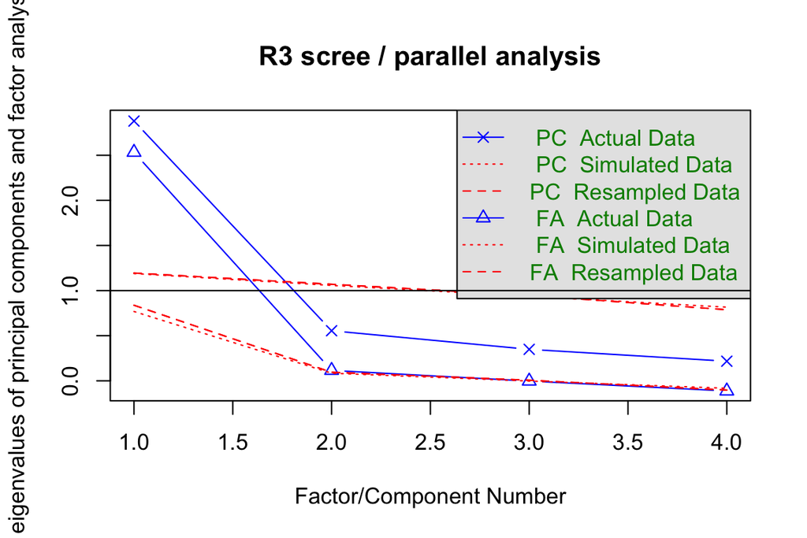

Figure 1: Scree plot with parallel analysis for the R3 items

```r
ev3 <- eigen(cor(r3))$values
```

The eigenvalues are 2.88, 0.55, 0.35, 0.22. Only the first is above 1, the scree plot bends sharply after factor 1, and parallel analysis also suggests **1 factor**. All three rules agree.

## Factor loadings (one factor, maximum likelihood)

```r
efa3 <- fa(r3, nfactors = 1, fm = "ml")
load3 <- data.frame(Item = r3_items,
                    Loading = round(as.numeric(efa3$loadings), 2),
                    Communality = round(efa3$communality, 2),
                    Uniqueness = round(efa3$uniquenesses, 2))
kable(load3, caption = "R3 one-factor solution")
```

R3 one-factor solution

|  | Item | Loading | Communality | Uniqueness |
| --- | --- | --- | --- | --- |
| q3 | q3 | 0.75 | 0.57 | 0.43 |
| q4 | q4 | 0.93 | 0.86 | 0.14 |
| q5 | q5 | 0.76 | 0.58 | 0.42 |
| q6 | q6 | 0.73 | 0.53 | 0.47 |

The single factor explains **63%** of the variance (ML), or 72% with PCA. Loadings range from 0.73 to 0.93, all well above .40 and mostly strong. Q4 (helpful) is the strongest. With one factor, no rotation is needed.

## Reliability

```r
cat("Cronbach's alpha (raw)  =", round(r3_a$total$raw_alpha, 2), "\n")
```

```
Cronbach's alpha (raw)  = 0.87
```

```r
cat("Cronbach's alpha (std)  =", round(r3_a$total$std.alpha, 2), "\n")
```

```
Cronbach's alpha (std)  = 0.87
```

```r
cat("Average inter-item r    =", round(r3_a$total$average_r, 2), "\n")
```

```
Average inter-item r    = 0.62
```

```r
kable(r3_a$alpha.drop[, c("raw_alpha", "std.alpha")], digits = 2,
      caption = "Alpha if item dropped")
```

Alpha if item dropped

|  | raw_alpha | std.alpha |
| --- | --- | --- |
| q3 | 0.85 | 0.86 |
| q4 | 0.79 | 0.79 |
| q5 | 0.82 | 0.83 |
| q6 | 0.85 | 0.85 |

```r
kable(r3_a$item.stats[, c("r.cor", "r.drop")], digits = 2,
      caption = "Corrected item-total correlations")
```

Corrected item-total correlations

|  | r.cor | r.drop |
| --- | --- | --- |
| q3 | 0.73 | 0.66 |
| q4 | 0.88 | 0.82 |
| q5 | 0.78 | 0.73 |
| q6 | 0.73 | 0.67 |

Cronbach’s alpha is **0.87**, which is above .70 (good internal consistency). Dropping any item would **lower** alpha, so every item is pulling its weight and none should be removed.

## Decision for R3

**Note**

**Build the composite.** One clear factor, strong loadings, and alpha of 0.87 support averaging Q3 to Q6 into a single **attitude toward employee proficiency** score and using that score in the R3 analysis.

# R6: Operational Effectiveness (metric items Q31 to Q34)

**Items:** Q31 confidential, Q32 prompt, Q33 meets members’ needs, Q34 loan applications simple.

## Correlations and descriptives

```r
kable(describe(r6)[, c("n", "mean", "sd", "min", "max")], digits = 2,
      caption = "R6 item descriptives")
```

R6 item descriptives

|  | n | mean | sd | min | max |
| --- | --- | --- | --- | --- | --- |
| q31 | 128 | 3.95 | 0.68 | 1 | 5 |
| q32 | 128 | 3.72 | 0.79 | 2 | 5 |
| q33 | 128 | 3.59 | 0.68 | 2 | 5 |
| q34 | 128 | 3.46 | 0.78 | 1 | 5 |

```r
kable(cor(r6), digits = 2, caption = "R6 inter-item correlations")
```

R6 inter-item correlations

|  | q31 | q32 | q33 | q34 |
| --- | --- | --- | --- | --- |
| q31 | 1.00 | 0.28 | 0.12 | 0.00 |
| q32 | 0.28 | 1.00 | 0.22 | 0.39 |
| q33 | 0.12 | 0.22 | 1.00 | 0.04 |
| q34 | 0.00 | 0.39 | 0.04 | 1.00 |

The correlations are **weak and uneven** (0.00 to .39). Q32 is the only item that correlates with more than one other item. Q31 with Q34 and Q33 with Q34 are close to zero.

## Is the data suitable for factor analysis?

```r
cat("KMO overall MSA =", round(r6_kb$kmo, 2), "\n")
```

```
KMO overall MSA = 0.5
```

```r
cat("Item MSAs:", paste(names(r6_kb$msa), round(r6_kb$msa, 2), collapse = ", "), "\n")
```

```
Item MSAs: q31 0.49, q32 0.5, q33 0.6, q34 0.46
```

```r
cat("Bartlett: chi-square(", r6_kb$df, ") = ", round(r6_kb$chisq, 1),
    ", p ", ifelse(r6_kb$p < .001, "< .001", paste("=", round(r6_kb$p, 3))), "\n", sep = "")
```

```
Bartlett: chi-square(6) = 39.3, p < .001
```

Bartlett’s test is significant, so there is *some* shared variance. But KMO is only **0.5**, which is right at the bare minimum, and three of the four item MSAs are at or below .50. **The data are marginal at best for factor analysis**, so I treat the loadings below with caution.

## How many factors?

```r
fa.parallel(r6, fa = "both", main = "R6 scree / parallel analysis")
```

```
Parallel analysis suggests that the number of factors =  2  and the number of components =  1
```

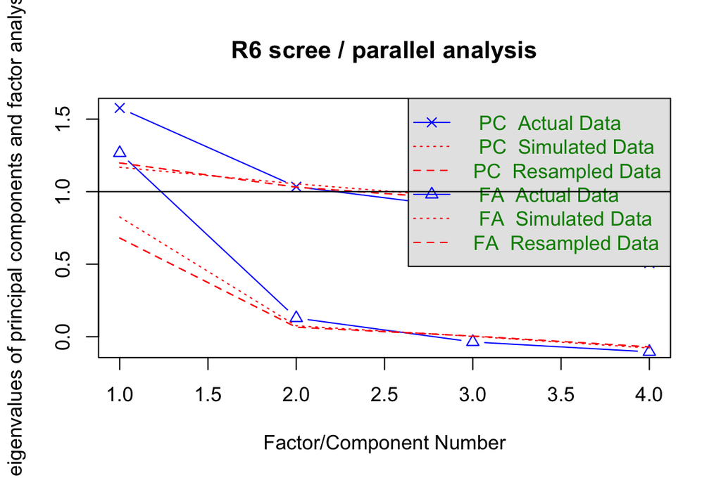

Figure 2: Scree plot with parallel analysis for the R6 items

```r
ev6 <- eigen(cor(r6))$values
```

## Factor loadings (one factor, maximum likelihood)

```r
efa6 <- fa(r6, nfactors = 1, fm = "ml")
pca6 <- principal(r6, nfactors = 1)
load6 <- data.frame(Item = r6_items,
                    `ML loading` = round(as.numeric(efa6$loadings), 2),
                    `PCA loading` = round(as.numeric(pca6$loadings), 2),
                    Communality = round(efa6$communality, 2),
                    check.names = FALSE)
kable(load6, caption = "R6 one-factor solution")
```

R6 one-factor solution

|  | Item | ML loading | PCA loading | Communality |
| --- | --- | --- | --- | --- |
| q31 | q31 | 0.28 | 0.51 | 0.08 |
| q32 | q32 | 1.00 | 0.84 | 1.00 |
| q33 | q33 | 0.22 | 0.48 | 0.05 |
| q34 | q34 | 0.39 | 0.61 | 0.15 |

The one factor explains only **32%** of the variance (ML), or 39% with PCA. The ML solution is unstable: Q32 loads at about 1.00 (a Heywood case, which means the model is putting nearly all the common variance on one item), while Q31 and Q33 load only about .2 to .3. PCA is more forgiving (loadings .5 to .8), but it tells the same story: **Q32 carries the factor and the other items hang on loosely.** The items do not look like one clean construct.

## Reliability

```r
cat("Cronbach's alpha (raw)  =", round(r6_a$total$raw_alpha, 2), "\n")
```

```
Cronbach's alpha (raw)  = 0.47
```

```r
cat("Cronbach's alpha (std)  =", round(r6_a$total$std.alpha, 2), "\n")
```

```
Cronbach's alpha (std)  = 0.46
```

```r
cat("Average inter-item r    =", round(r6_a$total$average_r, 2), "\n")
```

```
Average inter-item r    = 0.18
```

```r
kable(r6_a$alpha.drop[, c("raw_alpha", "std.alpha")], digits = 2,
      caption = "Alpha if item dropped")
```

Alpha if item dropped

|  | raw_alpha | std.alpha |
| --- | --- | --- |
| q31 | 0.47 | 0.46 |
| q32 | 0.14 | 0.15 |
| q33 | 0.47 | 0.46 |
| q34 | 0.44 | 0.44 |

```r
kable(r6_a$item.stats[, c("r.cor", "r.drop")], digits = 2,
      caption = "Corrected item-total correlations")
```

Corrected item-total correlations

|  | r.cor | r.drop |
| --- | --- | --- |
| q31 | 0.30 | 0.19 |
| q32 | 0.70 | 0.49 |
| q33 | 0.27 | 0.19 |
| q34 | 0.37 | 0.23 |

Cronbach’s alpha is only **0.47**, well below the .70 cutoff, and the average inter-item correlation is just 0.18. Dropping an item does not rescue it: alpha stays around .44 to .47 for every item except Q32, and removing Q32 drops it to about .14. Corrected item-total correlations are low (about .19 to .23) for Q31, Q33, and Q34.

## Decision for R6

**Do not build a composite.** Alpha of 0.47 is poor, KMO is marginal, the loadings are unstable, and no item deletion fixes it. Averaging Q31 to Q34 would blend items that do not measure one construct. In the next step I analyze **each item (Q31, Q32, Q33, Q34) on its own** for R6.

# Summary

```r
sumtab <- data.frame(
  Scale = c("R3 Employee proficiency (Q3 to Q6)", "R6 Operational effectiveness (Q31 to Q34)"),
  KMO = round(c(r3_kb$kmo, r6_kb$kmo), 2),
  `Bartlett p` = c("< .001", "< .001"),
  `Factors retained` = c(1, 1),
  `Alpha` = round(c(r3_a$total$raw_alpha, r6_a$total$raw_alpha), 2),
  Decision = c("Build composite", "Keep items separate"),
  check.names = FALSE
)
kable(sumtab, caption = "Reliability and factor analysis summary")
```

Reliability and factor analysis summary

| Scale | KMO | Bartlett p | Factors retained | Alpha | Decision |
| --- | --- | --- | --- | --- | --- |
| R3 Employee proficiency (Q3 to Q6) | 0.78 | < .001 | 1 | 0.87 | Build composite |
| R6 Operational effectiveness (Q31 to Q34) | 0.50 | < .001 | 1 | 0.47 | Keep items separate |

**Takeaway:** R3 is a clean, reliable one-factor scale, so I average its four items. R6 is not, so I analyze its items separately.

# Appendix

- GitHub repo: https://github.com/dmcpp26/ibm6500-assignments
- GitHub Pages: https://dmcpp26.github.io/ibm6500-assignments/IC-Case31-EFA/efa-reliability-case31-dmeza.html